# Playing with ggplot

Rachelle

21 June 2016

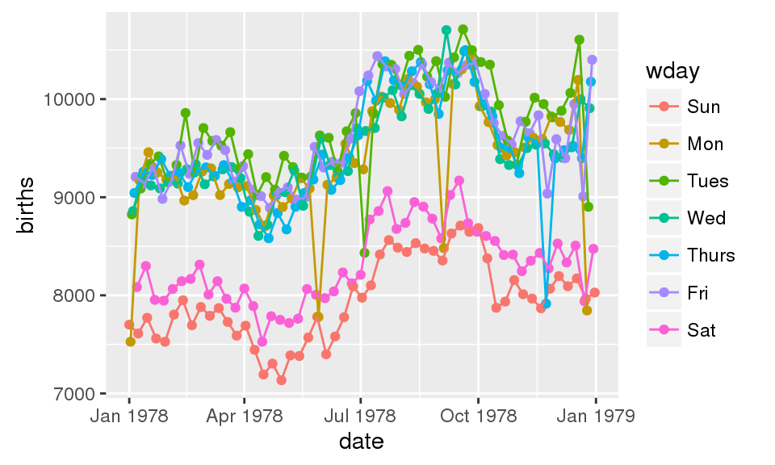

```r
Births78 %>%
ggplot(aes(x = date, y = births, color = wday)) + geom_point() + geom_line()
```

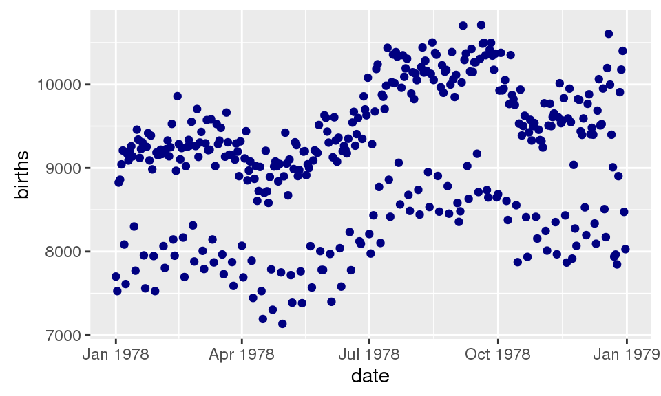

```r
Births78 %>%
ggplot(aes(x = date, y = births)) + geom_point(color = "navy")
```

ggplot doesn’t take color setting arguments, it chooses colors as a variable, not as something to be set. So if try to set the color inside ggplot, it’ll just assign a random color.

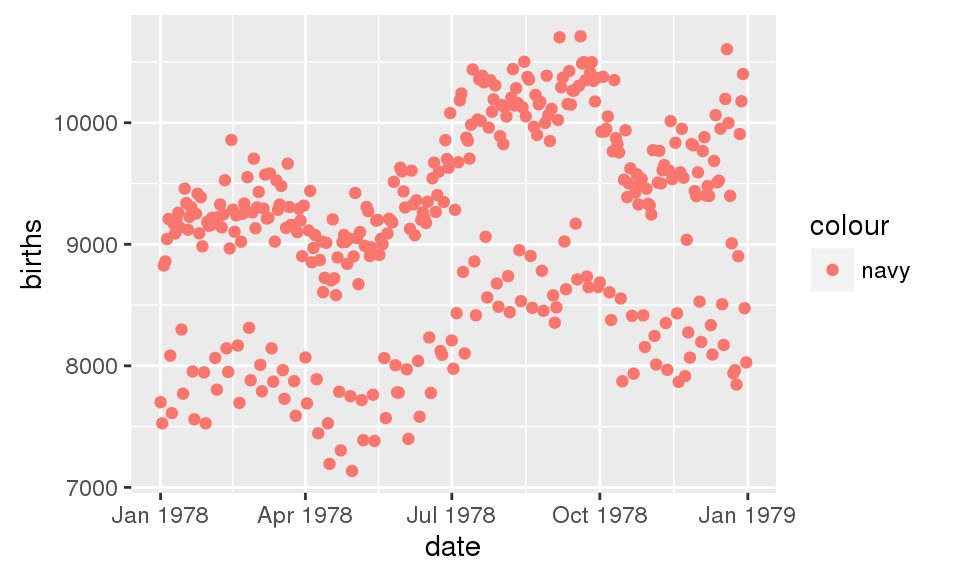

```r
Births78 %>%
ggplot(aes(x = date, y = births, color = "navy")) + geom_point()
```

Whichever layer you list first is drawn first.

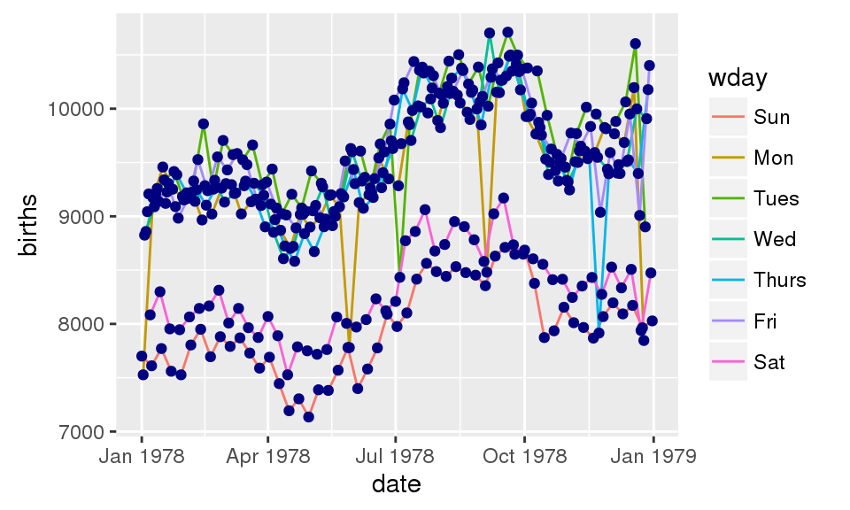

```r
Births78 %>%
ggplot(aes(x = date, y = births)) +
  geom_line(aes(color = wday)) +
  geom_point(color = "navy")
```

You can fill things in, but be careful not to obscure data. Also, filling in will take you down to zero to show the whole area under the curve. In a graph like the following one, that is useful to see, but it won’t always be useful. Perhaps transparency would be helpful here, or just a change in the y-axis instead of a fill.

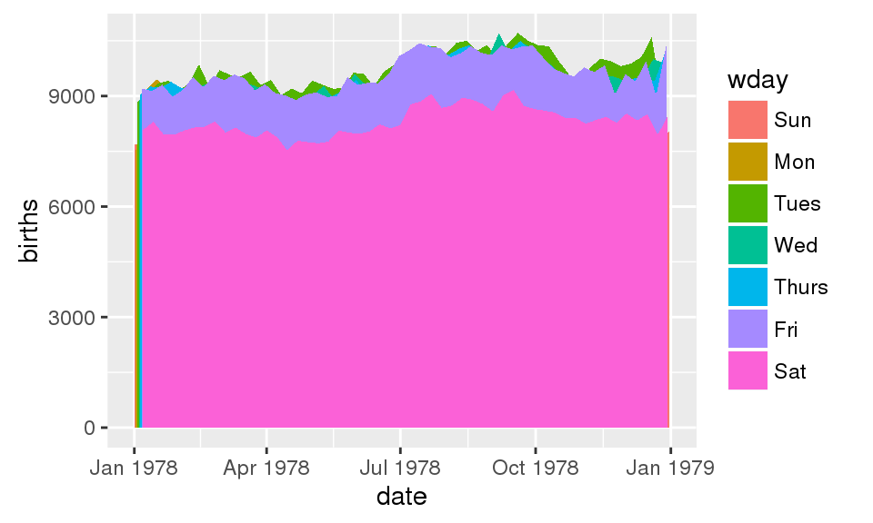

```r
Births78 %>%
ggplot(aes(x = date, y = births, fill = wday)) + geom_area()
```

The geom_bar function does the work of counting data into the bins you’ve chosen as your x variable.

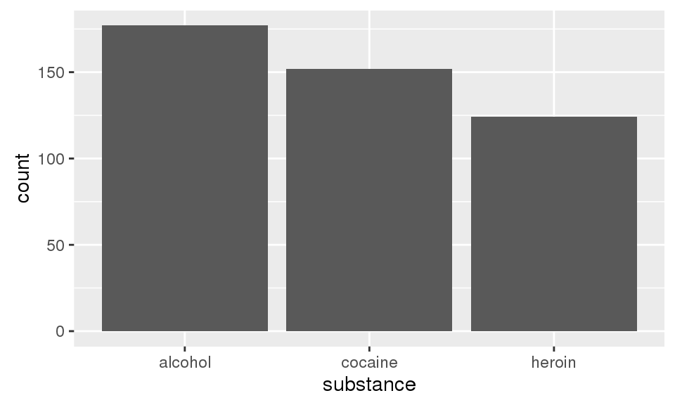

```r
HELPrct %>%
  ggplot(aes(x = substance)) + geom_bar()
```

There is a design flaw that the geom_bar draws the picture but doesn’t provide the actual account (for labeling or other purposes).

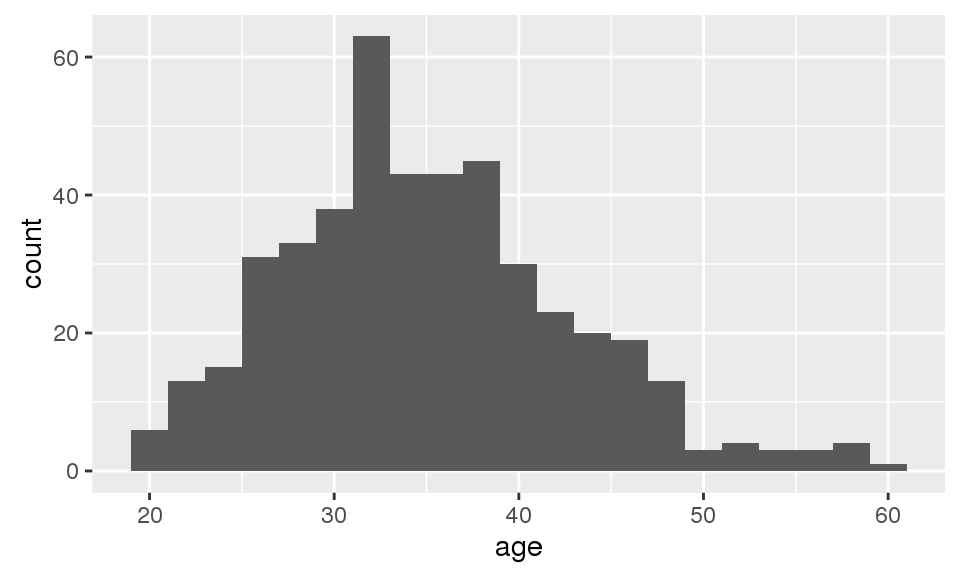

```r
HELPrct %>%
  ggplot(aes(x = age)) + geom_histogram(binwidth = 2)
```

You can change the number of bins instead of the binwidth.

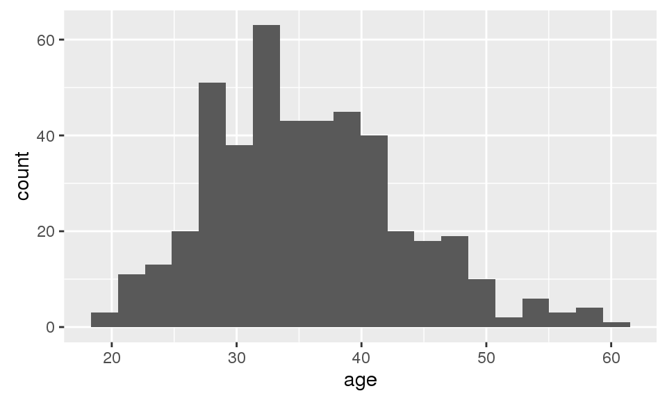

```r
HELPrct %>%
  ggplot(aes(x = age)) + geom_histogram(bins = 20)
```

Here are some other glyphs.

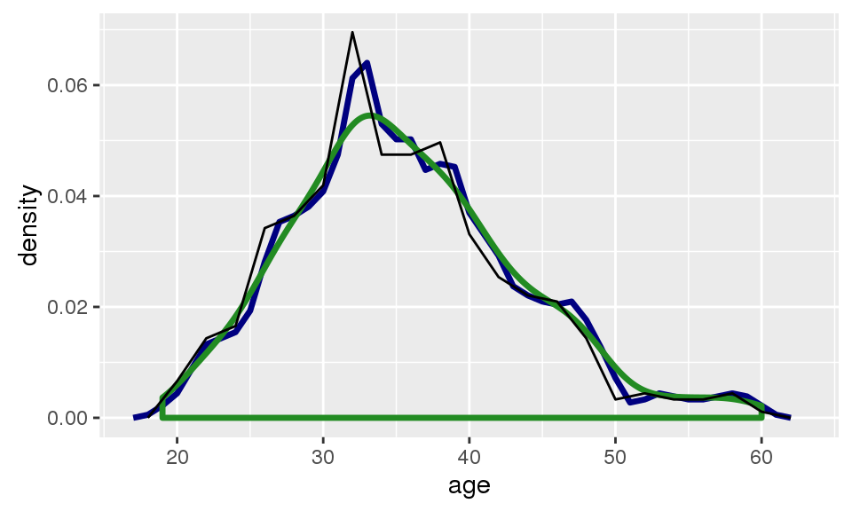

```r
HELPrct %>%
  ggplot(aes(x = age)) +
   geom_ash(binwidth = 2, colour = "navy", size = 1.2) +
   geom_density(colour = "forestgreen", size = 1.2) +
   geom_freqpoly(binwidth = 2, aes(y = ..density..))
```

```r
colors()
```

```
##   [1] "white"                "aliceblue"            "antiquewhite"
##   [4] "antiquewhite1"        "antiquewhite2"        "antiquewhite3"
##   [7] "antiquewhite4"        "aquamarine"           "aquamarine1"
##  [10] "aquamarine2"          "aquamarine3"          "aquamarine4"
##  [13] "azure"                "azure1"               "azure2"
##  [16] "azure3"               "azure4"               "beige"
##  [19] "bisque"               "bisque1"              "bisque2"
##  [22] "bisque3"              "bisque4"              "black"
##  [25] "blanchedalmond"       "blue"                 "blue1"
##  [28] "blue2"                "blue3"                "blue4"
##  [31] "blueviolet"           "brown"                "brown1"
##  [34] "brown2"               "brown3"               "brown4"
##  [37] "burlywood"            "burlywood1"           "burlywood2"
##  [40] "burlywood3"           "burlywood4"           "cadetblue"
##  [43] "cadetblue1"           "cadetblue2"           "cadetblue3"
```

[output cut: 204 more lines]

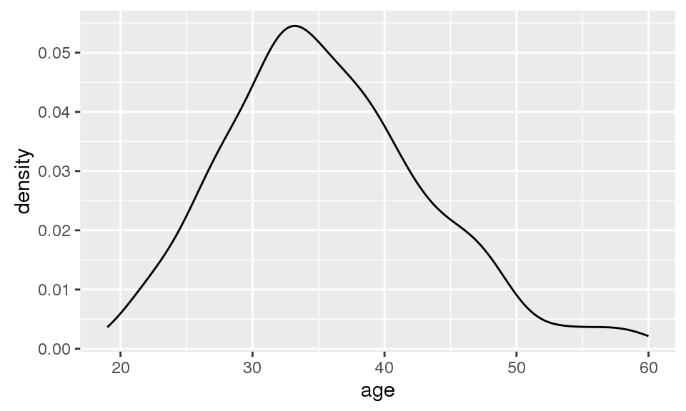

```r
HELPrct %>%
  ggplot(aes(x = age)) + geom_line(stat = "density")
```

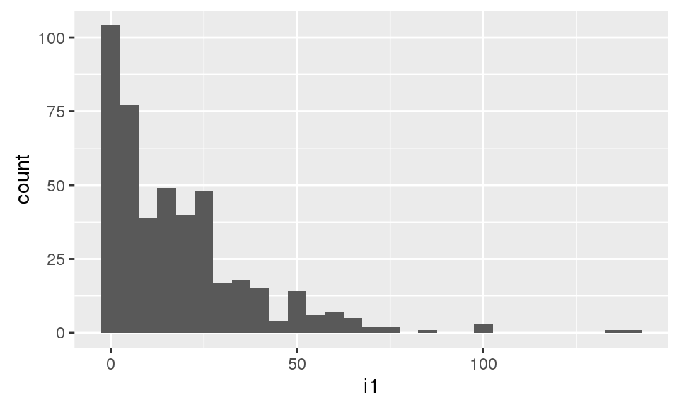

```r
HELPrct %>%
  ggplot(aes(x = i1)) + geom_histogram(binwidth = 5)
```

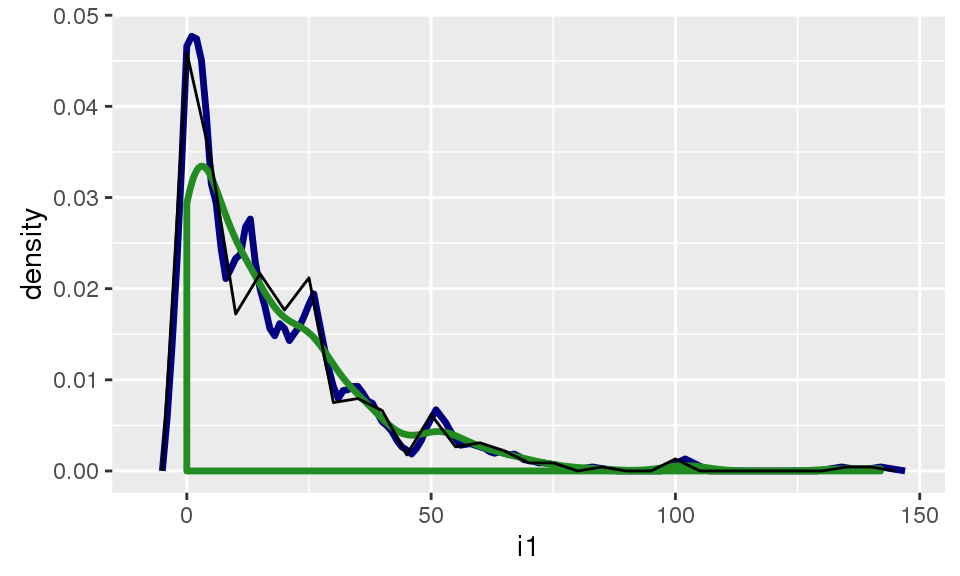

```r
HELPrct %>%
  ggplot(aes(x = i1)) +
   geom_ash(binwidth = 5, colour = "navy", size = 1.2) +
   geom_density(colour = "forestgreen", size = 1.2) +
   geom_freqpoly(binwidth = 5, aes(y = ..density..))
```

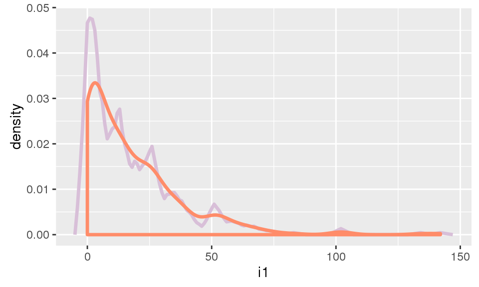

```r
HELPrct %>%
  ggplot(aes(x = i1)) +
   geom_ash(binwidth = 5, colour = "thistle", size = 1.2) +
   geom_density(colour = "salmon1", size = 1.2)
```

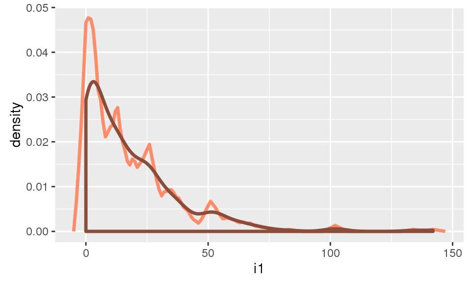

```r
HELPrct %>%
  ggplot(aes(x = i1)) +
   geom_ash(binwidth = 5, colour = "salmon1", size = 1.2) +
   geom_density(colour = "salmon4", size = 1.2)
```

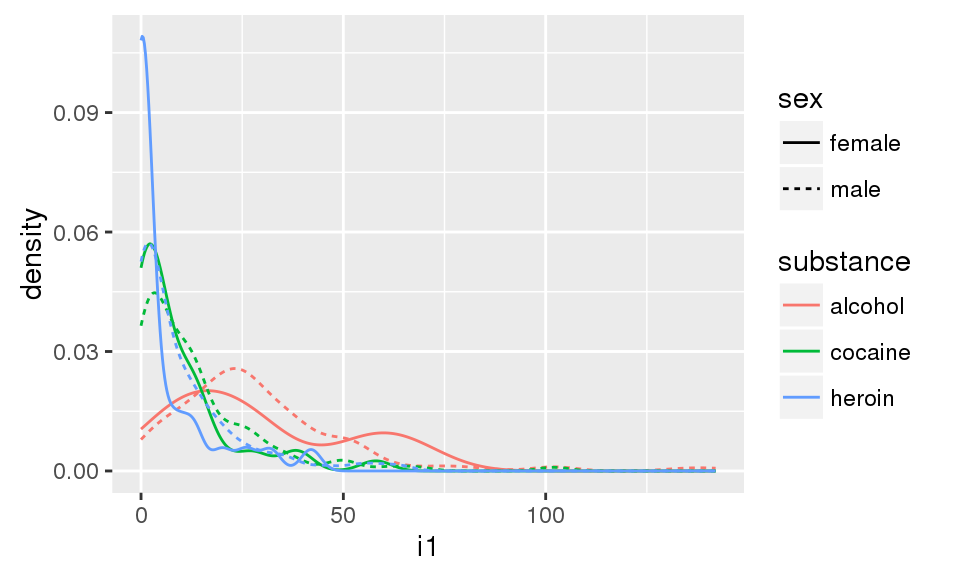

```r
HELPrct %>%
  ggplot(aes(x = i1, color = substance, linetype = sex)) +
   geom_line(stat = "density")
```

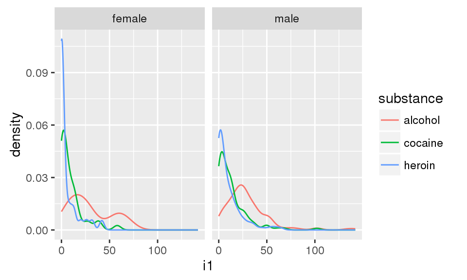

```r
HELPrct %>%
  ggplot(aes(x = i1, color = substance)) +
   geom_line(stat = "density") + facet_grid( . ~ sex)
```

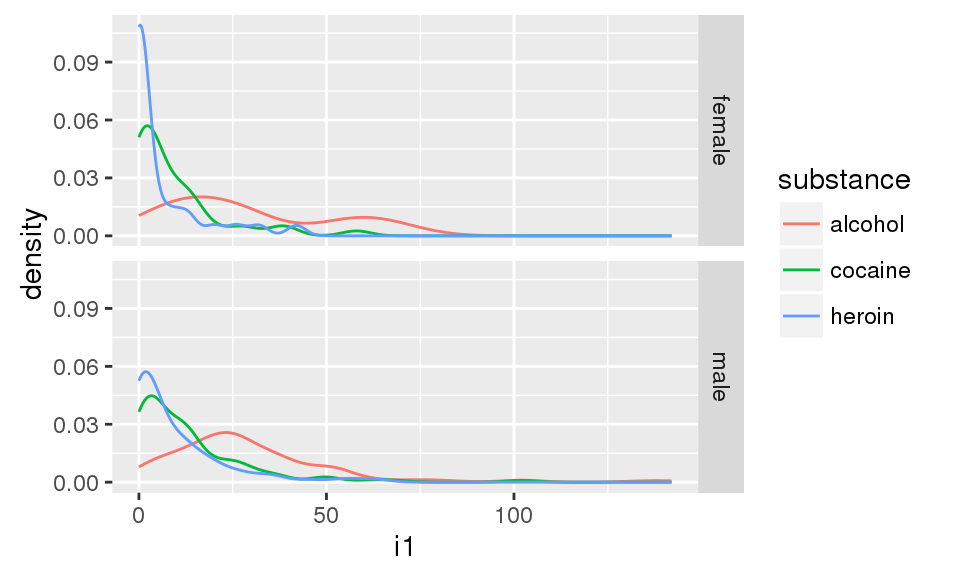

```r
HELPrct %>%
  ggplot(aes(x = i1, color = substance)) +
   geom_line(stat = "density") + facet_grid(sex ~ . )
```